# TrabajoSegmentacionDefinitivoTAE

## Entradas Transacción Promedio Mensual

### Construcción de la matriz de Componentes Principales

```python
# Entrenamiento modelo PCA con escalado de los datos
# ==============================================================================
pca_pipe_en_tx = make_pipeline(StandardScaler(), PCA())
pca_pipe_en_tx.fit(en_tx)
# Se extrae el modelo entrenado del pipeline
modelo_pca_en_tx = pca_pipe_en_tx.named_steps['pca']
#print(modelo_pca_en_tx.components_)
```

### Gráfico de Varianza Acumulada de los Componentes Principales

```
------------------------------------------
Porcentaje de varianza explicada acumulada
------------------------------------------
[0.14744097 0.2710404  0.35526389 0.42289396 0.48409494 0.53499251
 0.57951759 0.62130819 0.66097951 0.6970188  0.73282694 0.76558625
 0.79824342 0.82917354 0.85939863 0.88734837 0.91424308 0.93630785
 0.95047275 0.96355573 0.97223837 0.97804684 0.9834539  0.98876017
 0.99307315 0.99706822 1.        ]
```

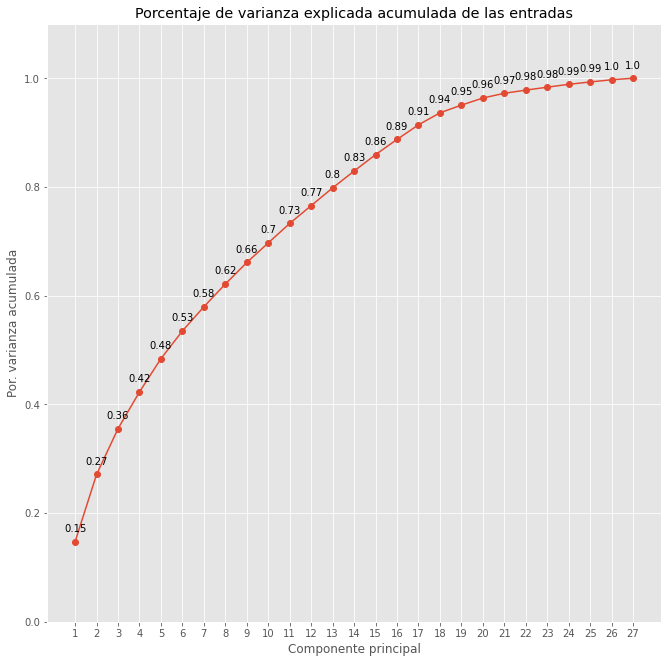

```python
# Porcentaje de varianza explicada acumulada [en_tx]
# ==============================================================================
prop_varianza_acum = modelo_pca_en_tx.explained_variance_ratio_.cumsum()
print('------------------------------------------')
print('Porcentaje de varianza explicada acumulada')
print('------------------------------------------')
print(prop_varianza_acum)

fig, ax = plt.subplots(nrows=1, ncols=1, figsize=(11, 11))
ax.plot(
    np.arange(len(en_tx.columns)) + 1,
    prop_varianza_acum,
    marker = 'o'
)

for x, y in zip(np.arange(len(en_tx.columns)) + 1, prop_varianza_acum):
    label = round(y, 2)
    ax.annotate(
        label,
        (x,y),
        textcoords="offset points",
        xytext=(0,10),
        ha='center'
    )

ax.set_ylim(0, 1.1)
ax.set_xticks(np.arange(modelo_pca_en_tx.n_components_) + 1)
ax.set_title('Porcentaje de varianza explicada acumulada de las entradas')
ax.set_xlabel('Componente principal')
ax.set_ylabel('Por. varianza acumulada')
```

Basados en la gráfica de varianza acumulada se tienen en cuenta las primeras 16 componentes principales para seguir realizando el análisis estadístico, con esto se reduce la base de datos de 27 variables a 16 componentes y estas explican aproximadamente un 90% de la variabilidad total.

### Proyección de la matriz de Componentes Principales para reducción de dimensionalidad

```python
# Proyección de las observaciones de en_tx  nos quedamos solamente con las 16 componentes sugeridas
# ==============================================================================
proyecciones_en_tx = np.dot(modelo_pca_en_tx.components_, scale(en_tx).T)
proyecciones_en_tx = pd.DataFrame(proyecciones_en_tx, index = ['PC1', 'PC2', 'PC3', 'PC4', 'PC5', 'PC6', 'PC7', 'PC8', 'PC9','PC10','PC11','PC12','PC13','PC14','PC15','PC16','PC17','PC18','PC19','PC20','PC21','PC22','PC23','PC24','PC25','PC26','PC27'])
proyecciones_en_tx = proyecciones_en_tx.transpose().set_index(en_tx.index)
proyecciones_en_tx = proyecciones_en_tx.iloc[:, :16]
proyecciones_en_tx
```

|  | PC1 | PC2 | PC3 | PC4 | PC5 | PC6 | PC7 | PC8 | PC9 | PC10 | PC11 | PC12 | PC13 | PC14 | PC15 | PC16 |
| --- | --- | --- | --- | --- | --- | --- | --- | --- | --- | --- | --- | --- | --- | --- | --- | --- |
| 1 | -1.877809 | -0.013343 | 0.761423 | -0.858428 | 0.581765 | -1.957349 | -0.289599 | -1.445989 | 1.446915 | 0.367069 | 0.104048 | 0.348884 | -0.064292 | -0.411351 | -0.194356 | 0.461916 |
| 2 | -2.340969 | 1.950723 | -0.610847 | -0.059452 | 0.053679 | 0.021284 | 0.199346 | 0.544820 | -1.272731 | -0.255240 | -0.162213 | 0.222961 | 0.007506 | 0.196837 | -0.578903 | -0.666440 |
| 3 | -0.995452 | -1.157388 | 0.875109 | 0.621838 | 0.518353 | 0.970325 | 0.194220 | 1.445161 | -0.583765 | -0.000754 | -0.879732 | -0.128769 | -0.067616 | -0.038692 | -0.521752 | -0.477043 |
| 4 | -2.288488 | 0.446772 | 0.661098 | -0.438859 | 1.841461 | -1.010759 | -0.089253 | -0.304464 | 0.012263 | 0.033617 | -0.411562 | 0.538072 | -0.046394 | -0.174082 | -1.012725 | -0.497078 |
| 5 | -1.913213 | -0.315280 | 0.939536 | 1.098068 | -0.637221 | -0.979446 | -0.107374 | -0.622578 | 1.604072 | 0.474088 | -0.732101 | -0.191864 | -0.100479 | -0.446013 | 0.027030 | 0.340169 |
| ... | ... | ... | ... | ... | ... | ... | ... | ... | ... | ... | ... | ... | ... | ... | ... | ... |
| 2228 | 1.541845 | -2.009061 | 0.640977 | 0.391683 | -1.972812 | -2.393915 | 0.964763 | -0.864703 | -1.232056 | 0.015274 | 0.871785 | 0.086784 | 0.141984 | 0.326961 | 0.684379 | -0.127358 |
| 2229 | -1.135299 | -1.098578 | 1.087166 | 1.851618 | -0.730089 | -0.657071 | 0.248295 | -1.043739 | 0.882538 | 0.409388 | -0.081327 | 0.028043 | 0.019332 | -0.099265 | 0.380897 | -0.014638 |
| 2230 | -1.570378 | 0.517388 | 0.055164 | 0.655316 | -0.523148 | -0.569685 | 0.016665 | -1.576643 | 0.501104 | 0.196164 | 0.685872 | 0.325694 | -0.057536 | 0.100349 | 0.358305 | -0.111543 |
| 2231 | -2.470343 | 1.318530 | -0.136764 | 0.196614 | -0.482921 | -0.433484 | -0.076273 | -0.903889 | 0.524735 | 0.090715 | 0.305711 | 0.030739 | -0.072870 | 0.020574 | 0.357436 | 0.023830 |
| 2232 | -2.843076 | 1.649672 | -0.241016 | -0.702596 | -0.719369 | -0.669539 | 0.448258 | 0.973987 | -0.992627 | -0.420647 | -0.001999 | -0.752394 | 0.012170 | 0.231183 | 0.783077 | 0.046346 |

2232 rows × 16 columns

### Gráfico de Codo para hallar el número óptimo de Clusters

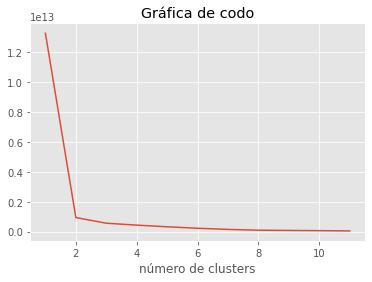

```python
#Revisando cuantos clusters son convenientes en_vm
from sklearn.cluster import KMeans
wcss = []
for i in range(1, 12):
  kmeans = KMeans(n_clusters = i, max_iter =300)
  kmeans.fit(en_tx)
  wcss.append(kmeans.inertia_)


#ploteamos gráfica de codo
plt.plot(range(1, 12), wcss)
plt.title("Gráfica de codo")
plt.xlabel("número de clusters")
plt.show()

#### 2 grupos se puede dividir la muestra
```

Mediante el gráfico se puede se interpretar que los Cluster necesarios para realizar una separación sugerida para los clientes es de 2 grupos.

### Dendograma

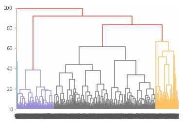

```python
#Dendograma de clusters_ dataset en_tx
clustering_en_tx = linkage(proyecciones_en_tx, 'ward')

dendograma_en_tx = sch.dendrogram(clustering_en_tx)
```

Podemos ver que el dendograma nos sugiere 3 grupos y el gráfico de codo 2, decidimos realizar la separación de los clientes en 3 grupos

### Análisis y conclusiones de la segmentación

```python
#proyecciones_en_tx_pca = pca_pipe_en_tx.transform(en_tx)
clusters_en_tx = fcluster(clustering_en_tx, t = 3, criterion='maxclust')
proyecciones_en_tx['Clustering jerarquico'] = clusters_en_tx
en_tx_aux = en_tx.copy()
en_tx_aux['Clustering jerarquico'] = clusters_en_tx
```

```python
en_tx_aux['Clustering jerarquico'].value_counts()
```

```
3    1711
2     510
1      11
Name: Clustering jerarquico, dtype: int64
```

- Los clientes del grupo 1 tiende a mover mucho más dinero de entradas medias anuales por todos los canales, exceptuando el canal 6.
- Los clientes del grupo 2 tiende a mover menos dinero por todos los canales.
- Por consecuencia los clientes del grupo 3 son los que tiene un valor de medio de entradas medias anuales por estos canales.

Analizando las variables de estado financiero y características de los clientes se obtiene la siguiente información:

- Los pagos que realizan los clientes del grupo 1 son aproximadamente el 70% son para personas jurídicas
- Los pagos que realizan los clientes del grupo 2 son aproximadamente el 60% son para personas jurídicas
- Los pagos que realizan los clientes del grupo 3 son aproximadamente el 50% para personas jurídicas y naturales
- Las cuentas por pagar (cxp) de los clientes del grupo 1 son mucho mayores en comparación a los demás grupos de clientes, lo cual puede estar relacionado con el flujo entradas de valor medio anual por ticket por los distintos canales
- Similar al analisis anterior la componenete cxc es marcamente diferente en los diferentes cluster formados lo que la hace una buena variable para caraterizar a un determinado usuario como perteneciente o no a un grupo en específico
- Para los clientes del grupo 1 la mediana de las variables *cxc* y *cxp* es de 6, por lo tanto, a estos clientes se les puede asignar una prioridad para la utilización de los canales 1,3 y otros para sus entradas de dinero por transacciones mensuales promedio

## Salidas Valor Promedio Anual del Ticket

### Construcción de la matriz de Componentes Principales

```python
# Entrenamiento modelo PCA con escalado de los datos
# ==============================================================================
pca_pipe_sal_vm = make_pipeline(StandardScaler(), PCA())
pca_pipe_sal_vm.fit(sal_vm)
# Se extrae el modelo entrenado del pipeline
modelo_pca_sal_vm = pca_pipe_sal_vm.named_steps['pca']
```

### Gráfico de Varianza Acumulada de los Componentes Principales

```
------------------------------------------
Porcentaje de varianza explicada acumulada
------------------------------------------
[0.18263463 0.31835792 0.40889168 0.4915499  0.56078861 0.62606725
 0.68188749 0.73447062 0.78433809 0.83352152 0.87519381 0.91416417
 0.94961254 0.96209382 0.97013177 0.9775234  0.98479645 0.99063478
 0.99603663 1.        ]
```

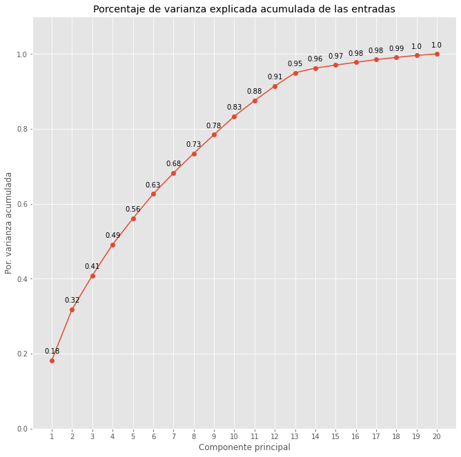

```python
# Porcentaje de varianza explicada acumulada [sal_vm]
# ==============================================================================
prop_varianza_acum = modelo_pca_sal_vm.explained_variance_ratio_.cumsum()
print('------------------------------------------')
print('Porcentaje de varianza explicada acumulada')
print('------------------------------------------')
print(prop_varianza_acum)

fig, ax = plt.subplots(nrows=1, ncols=1, figsize=(11, 11))
ax.plot(
    np.arange(len(sal_vm.columns)) + 1,
    prop_varianza_acum,
    marker = 'o'
)

for x, y in zip(np.arange(len(sal_vm.columns)) + 1, prop_varianza_acum):
    label = round(y, 2)
    ax.annotate(
        label,
        (x,y),
        textcoords="offset points",
        xytext=(0,10),
        ha='center'
    )

ax.set_ylim(0, 1.1)
ax.set_xticks(np.arange(modelo_pca_sal_vm.n_components_) + 1)
ax.set_title('Porcentaje de varianza explicada acumulada de las entradas')
ax.set_xlabel('Componente principal')
ax.set_ylabel('Por. varianza acumulada')
```

Basados en la gráfica de varianza acumulada se tienen en cuenta las primeras 13 componentes principales para seguir realizando el análisis estadístico, con esto se reduce la base de datos de 20 variables a 13 componentes y estas explican aproximadamente un 95% de la variabilidad total

```python
# Proyección de las observaciones de sal_vm nos quedamos solamente con las 16 componentes sugeridas
# ==============================================================================
proyecciones_sal_vm = np.dot(modelo_pca_sal_vm.components_, scale(sal_vm).T)
proyecciones_sal_vm = pd.DataFrame(proyecciones_sal_vm, index = ['PC1', 'PC2', 'PC3', 'PC4', 'PC5', 'PC6', 'PC7', 'PC8', 'PC9','PC10','PC11','PC12','PC13','PC14','PC15','PC16','PC17','PC18','PC19','PC20'])
proyecciones_sal_vm = proyecciones_sal_vm.transpose().set_index(sal_vm.index)
proyecciones_sal_vm = proyecciones_sal_vm.iloc[:, :13]
proyecciones_sal_vm
```

|  | PC1 | PC2 | PC3 | PC4 | PC5 | PC6 | PC7 | PC8 | PC9 | PC10 | PC11 | PC12 | PC13 |
| --- | --- | --- | --- | --- | --- | --- | --- | --- | --- | --- | --- | --- | --- |
| 1 | -1.515451 | -1.025000 | -0.646369 | 1.107060 | -1.711412 | 0.656939 | -1.674980 | 1.215203 | -0.795055 | 0.063047 | 0.485979 | -0.119693 | 0.089246 |
| 2 | -2.944023 | 0.794628 | -0.167735 | -0.121965 | 0.153270 | 0.203903 | 0.625063 | -1.270219 | 0.530714 | -0.320744 | 0.326308 | 0.642335 | -0.256372 |
| 3 | -0.180661 | -1.652128 | 0.651857 | 0.252061 | 0.984367 | -0.134598 | 1.514930 | -0.190850 | 0.904963 | -0.309143 | 0.425516 | 0.640578 | -0.091483 |
| 4 | -2.820505 | -0.296554 | -0.261841 | 1.060567 | 0.848624 | 2.929233 | -10.088249 | 1.785989 | 26.046606 | 25.025222 | -0.028296 | -2.045023 | -0.674692 |
| 5 | -1.385594 | -1.308206 | 1.312937 | -0.170604 | -1.326800 | -0.092075 | -0.441109 | 1.766440 | -0.499309 | 0.206434 | 0.388268 | 0.036865 | 0.075159 |
| ... | ... | ... | ... | ... | ... | ... | ... | ... | ... | ... | ... | ... | ... |
| 2228 | 2.608813 | -0.389636 | 0.841942 | -0.438777 | -3.039249 | -0.096055 | -0.317175 | -1.502089 | -0.458283 | 0.487680 | -0.812011 | -0.514580 | -0.063470 |
| 2229 | -0.298364 | -1.587365 | 2.052694 | -0.376980 | -1.024955 | -0.280836 | -0.799034 | 0.700097 | -0.684105 | 0.347524 | -0.155778 | 0.047116 | 0.013707 |
| 2230 | -1.500977 | -0.094967 | 0.706636 | -0.337934 | -0.715693 | -0.158567 | -1.504929 | 0.018015 | -0.951513 | 0.292963 | -0.269667 | -0.031554 | -0.025861 |
| 2231 | -2.698677 | 0.144469 | 0.217000 | -0.311694 | -0.625312 | -0.180548 | -0.758720 | 0.318399 | -0.681512 | 0.236841 | -0.223201 | -0.134281 | -0.008653 |
| 2232 | -3.165715 | 0.348654 | -0.607143 | -0.119812 | -1.067270 | -0.272709 | 1.546846 | -0.702173 | 0.154759 | 0.258159 | -0.786391 | -0.609908 | -0.024332 |

2232 rows × 13 columns

### Gráfico de Codo para hallar el número óptimo de Clusters

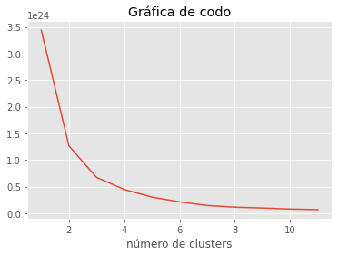

```python
#Revisando cuantos clusters son convenientes sal_vm
from sklearn.cluster import KMeans
wcss = []
for i in range(1, 12):
  kmeans = KMeans(n_clusters = i, max_iter =300)
  kmeans.fit(sal_vm)
  wcss.append(kmeans.inertia_)


#ploteamos gráfica de codo
plt.plot(range(1, 12), wcss)
plt.title("Gráfica de codo")
plt.xlabel("número de clusters")
plt.show()
```

En base al gráfico de codo este sugiere separar los clientes en 2 ó 3 grupos

### Dendograma

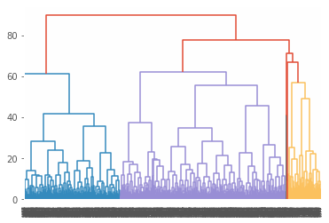

```python
#Dendograma de clusters_ dataset sal_vm
clustering_sal_vm = linkage(proyecciones_sal_vm, 'ward')
dendograma_sal_vm = sch.dendrogram(clustering_sal_vm)
```

Podemos ver que el dendograma nos sugiere 3 grupos y el grafico de codo 2 ó 3, se decide realizar la separación en los 3 grupos de clientes

### Análisis y conclusiones de la segmentación

```python
#proyecciones_sal_vm_pca = pca_pipe_sal_vm.transform(sal_vm)
clusters_sal_vm = fcluster(clustering_sal_vm, t = 3, criterion='maxclust')
proyecciones_sal_vm['Clustering jerarquico'] = clusters_sal_vm
sal_vm_aux = sal_vm.copy()
sal_vm_aux['Clustering jerarquico'] = clusters_sal_vm
```

```python
sal_vm_aux['Clustering jerarquico'].value_counts()
```

```
2    1243
1     727
3     262
Name: Clustering jerarquico, dtype: int64
```

- Los clientes del grupo 3 tienden mueven mucho más dinero por los diferentes canales 2, 5 y 8.
- Los clientes del grupo 2 tiene valores promedio de tickets en los canales 2 y 5 mayores en comparacion a los clientes del grupo 1 y los tickets promedio para estos son mayores en los canales 8 y otros, por lo tanto con este análisis es posible inferir que la variable de salida en canales 2 y 5 es altamente influyente en la conformación de los cluster ya que su valor difirie sustancialmente entre grupos
- Se podrian habilitar los canales 2 y 5 priorizando los clientes del grupo 2 y los canales 8 y otros para los clientes del grupo 1 y si son del grupo 3 se priorizan por cualquier canal.

Analizando las variables de estado financiero y características de los clientes se obtiene la siguiente información:

- Los pagos que realizan los clientes del grupo 3 son aproximadamente el 60% son para personas naturales
- Los pagos que realizan los clientes del grupo 1 son aproximadamente el 50% son para personas jurídicas y naturales
- Los pagos que realizan los clientes del grupo 2 son aproximadamente el 60% para personas jurídica